# Bland-Altman report

blandr report automated tool

August 04, 2017

## Preamble

This is an autogenerated report from the blandr R library. This report relies on the data being supplied to be accurate. Whilst it tries to provide some information on the data provided, it *IS NOT* a replacement for proper review (and sense checks) of the data. It is also *NOT* a replacement for formal statistical advice.

The *blandr report automated tool* is intended to be a tool for the start of exploration of the data generated. Statistical agreement (or lack of) does not mean that there is no clinical (or “practical”) agreement: what level of acceptable agreement should be defined before this tool is used. All use of the statistics provided is at the user’s own risk.

## Interpreting the output

The two methods used in the comparison will be labelled “Method 1” and “Method 2”. It is up to the user to understand which data they have supplied as these methods.

Questions to think about when interepreting the data include:

1. Should the two methods be compared?
2. Is the data correct?
3. *A priori*, what can be thought of as acceptable practical agreement?
4. In the data is there statistical agreement? (For all intents and purposed this will not be true)
5. In the data is there practical agreement?
6. What conclusions can be drawn from the data?

A suggestion by Chhapola et al. on reporting the data includes:

1. correct representation of x-axis on B-A plot
2. representation and correct definition of limits of agreement (LOA)
3. reporting of confidence interval (CI) of LOA
4. comparison of LOA with a priori defined clinical criteria
5. evaluation of the pattern of the relationship between difference (y-axis) and average (x-axis)
6. measures of repeatability.

This paper can be found at doi:10.1177/0004563214553438

## Description of the plots

The dashed lines represent the summary Bland-Altman statistical data, namely: (1) bias, (2) upper limit of agreement, (3) lower limit of agreement. The dotted line (when present) represent confidence intervals for the summary statistics.

## Summary statistics of “Method 1”

```r
method1
```

```
##  [1] 494 395 516 434 476 557 413 442 650 433 417 656 267 478 178 423 427
```

```r
summary(method1)
```

```
##    Min. 1st Qu.  Median    Mean 3rd Qu.    Max.
##   178.0   417.0   434.0   450.4   494.0   656.0
```

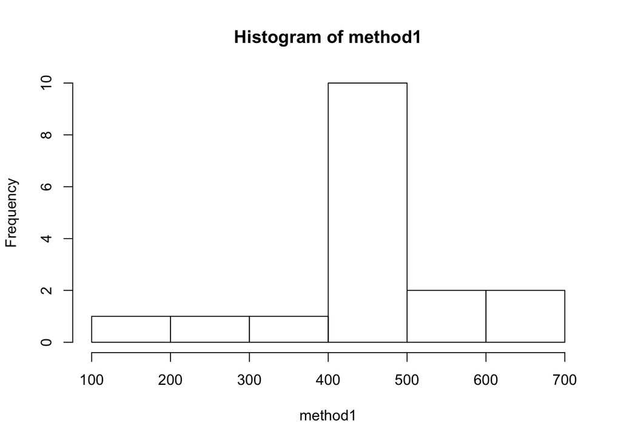

```r
hist(method1)
```

## Summary statistics of “Method 2”

```r
method2
```

```
##  [1] 512 430 520 428 500 600 364 380 658 445 432 626 260 477 259 350 451
```

```r
summary(method2)
```

```
##    Min. 1st Qu.  Median    Mean 3rd Qu.    Max.
##   259.0   380.0   445.0   452.5   512.0   658.0
```

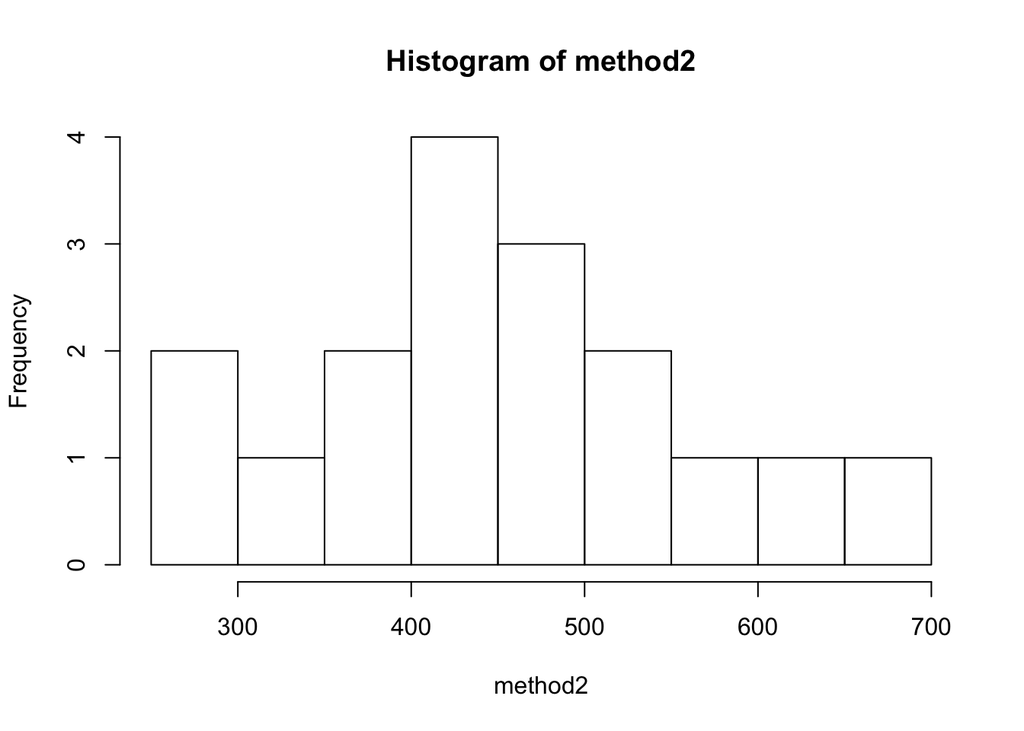

```r
hist(method2)
```

## Comparison of the two data sets

### Raw data output

```r
blandr.display ( method1 , method2 , sig.level=0.95 )
```

```
## Number of comparisons:  17
## Maximum value for average measures:  654
## Minimum value for average measures:  218.5
## Maximum value for difference in measures:  73
## Minimum value for difference in measures:  -81
##
## Bias:  -2.117647
## Standard deviation of bias:  38.76513
##
## Standard error of bias:  9.401925
## Standard error for limits of agreement:  16.39491
##
## Bias:  -2.117647
## Bias- upper 95% CI:  17.81354
## Bias- lower 95% CI:  -22.04884
##
## Upper limit of agreement:  73.86201
## Upper LOA- upper 95% CI:  108.6177
## Upper LOA- lower 95% CI:  39.10636
##
## Lower limit of agreement:  -78.0973
## Lower LOA- upper 95% CI:  -43.34165
## Lower LOA- lower 95% CI:  -112.8529
##
## Derived measures:
## Mean of differences/means:  -1.158314
## Point estimate of bias as proportion of lowest average:  -0.9691749
## Point estimate of bias as proportion of highest average -0.3237992
## Spread of data between lower and upper LoAs:  151.9593
## Bias as proportion of LoA spread:  -1.393562
##
## Bias:
##  -2.117647  ( -22.04884  to  17.81354 )
## ULoA:
##  73.86201  ( 39.10636  to  108.6177 )
## LLoA:
##  -78.0973  ( -112.8529  to  -43.34165 )
```

## Plot comparison of the two methods

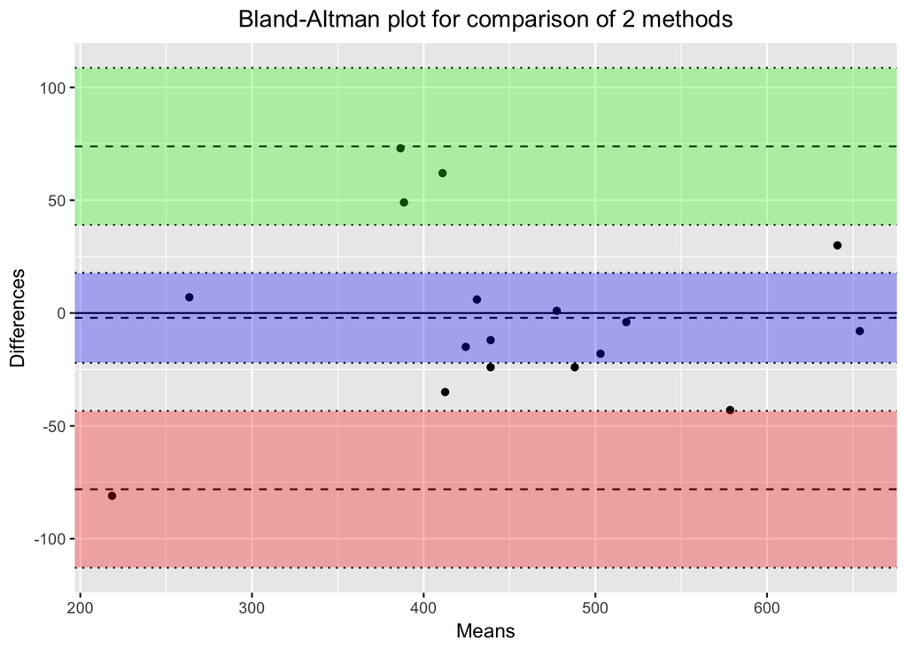

```r
blandr.draw ( method1 , method2 , sig.level=0.95 )
```

## Plot comparison with best fit line to investigate for proportional bias

```r
blandr.proportional.bias ( method1 , method2 , sig.level=0.95 )
```

```
## [1] "y = 0.029x + -15"
```

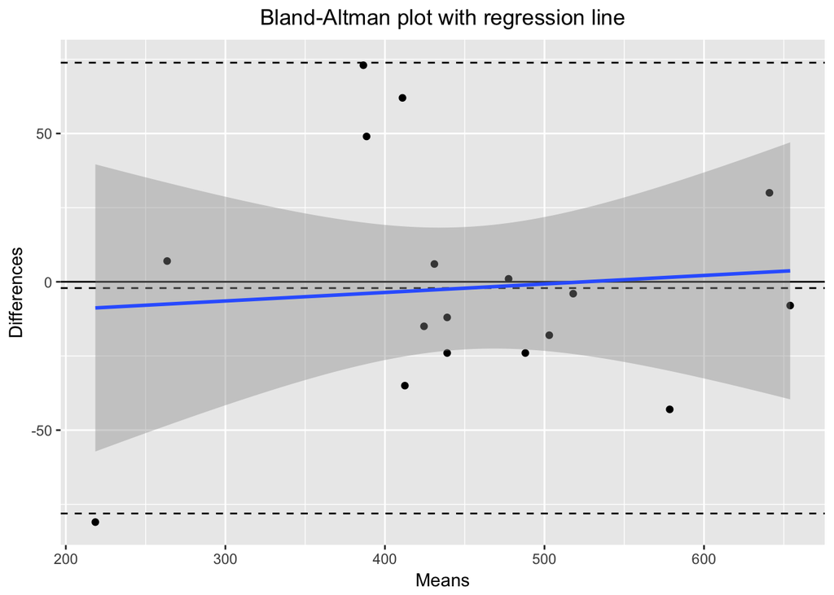

## Additional comparison data

```r
blandr.method.comparison ( method1 , method2 , sig.level=0.95 )
```

```
##
## Note as per Bland and Altman 1986 linear correlation DOES NOT mean agreement. Data which seem to be in poor agreement can produce quite high correlations. Line of equality in dashed black, linear regression model in solid red.
```

[figure not shown]

```
##
## Paired T-tests evaluate for significant differences between the means of two sets of data. It does not test agreement, as the results of a T-test can be hidden by the distribution of differences. See the references for further reading.
## Paired T-test p-value:  0.8246477
##
## Correlation coefficients only tell us the linear relationship between 2 variables and nothing about agreement.
## Correlation coefficient: 0.9432794
##
## Linear regression models, are conceptually similar to correlation coefficients, and again tell us nothing about agreement.
## Using method 1 to predict the dependent method 2, using least squares regression.
## Regression equation: method 2 =  0.9699441 x method 1 +  11.48178
```